# PieDonut Plot 만들기

Pie chart 와 donut chart를 결합한 PieDonut plot을 만들고자 합니다. 여러가지 방법이 있겠지만 저는 ggforce 패키지의 geom_arc_bar() 함수를 이용하였습니다. ggforce 패키지의 vignette는 여기서 보실 수 있습니다.

https://cran.r-project.org/web/packages/ggforce/vignettes/Visual_Guide.html

## 오늘의 문제

moonBook패키지의 acs데이터를 이용하여 다음과 같은 그림을 그리는 것이 문제였습니다.

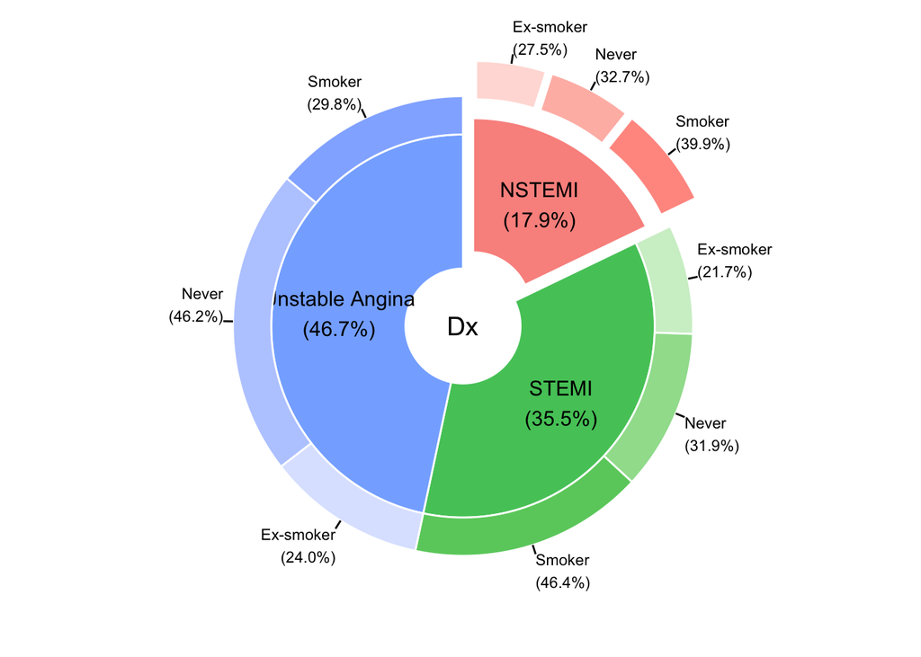

이 그림은 먼저 진단명으로 pie chart를 그리고 각 진단명에 해당하는 환자들의 흡연상태에 따라 세군으로 나누어 같은 계통의 색깔로 doughnut plot을 그린 것입니다

## PieDonut()함수의 이용

위의 그림를 그리기 위해 PieDonut()함수를 만들어 webr패키지에 넣었습니다. 다음 명령어를 사용하시면 됩니다.

```r
require(moonBook)
require(ggplot2)
require(webr)

PieDonut(acs,aes(Dx,smoking),explode=1,explodeDonut=TRUE,labelposition=1)
```

또한 이 함수의 자세한 사용 예는 다음에 있습니다. 단순히 이 함수를 사용하기를 원하시는 분들은 다음의 사용 예만 읽어보시면 됩니다.

http://rpubs.com/cardiomoon/398623

## 어떻게 그릴 것인가?

먼저 이 그림은 가운데의 pie chart와 주변의 donut chart로 나누어 생각해야 합니다. 먼저 pie chart 를 그리고 pie chart의 색깔을 알아낸 후 흰색에서부터 원하는 색깔로 변해가는 gradient color를 만들어 doughnut의 색깔을 입히면 되겠습니다.

## 필요한 패키지 불러오기

다음 패키지들이 필요합니다.

```r
require(moonBook)
require(ztable)
require(ggplot2)
require(dplyr)
require(ggforce)
```

## 1. 준비운동

ggforce 패키지의 geom_arc_bar()함수를 어떻게 쓸까요? ggforce 패키지 설명서에 있는 예제를 한번 보겠습니다. pie라는 data.frame을 정의합니다.

```r
pie <- data.frame(
    state = c('eaten', 'eaten but said you didn\'t', 'cat took it',
              'for tonight', 'will decompose slowly'),
    start = c(0, 1, 2, 3, 4),
    end = c(1, 2, 3, 4, 2*pi),
    focus = c(0.2, 0, 0, 0, 0),
    stringsAsFactors = FALSE
)
pie
```

```
                      state start      end focus
1                     eaten     0 1.000000   0.2
2 eaten but said you didn't     1 2.000000   0.0
3               cat took it     2 3.000000   0.0
4               for tonight     3 4.000000   0.0
5     will decompose slowly     4 6.283185   0.0
```

이 데이터는 모두 5개의 파이로 되어있고 start는 파이의 시작각도(radian), end는 파이의 끝각도, focus는 튀어나오는 거리가 담겨 있습니다. 이 데이터를 이용하여 pie chart 를 그리려면 다음과 같이 합니다.

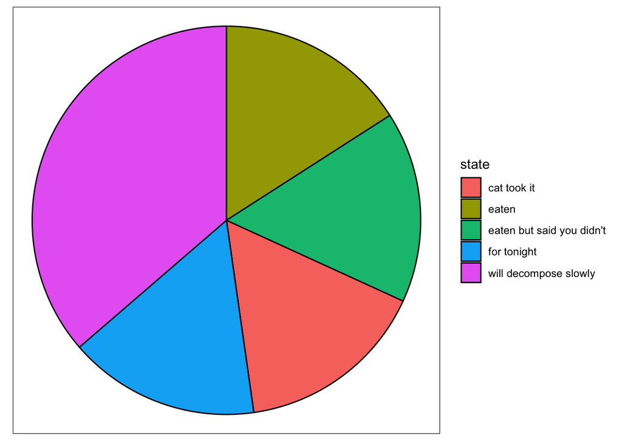

```r
p <- ggplot() + theme_no_axes() + coord_fixed()

# For low level control you define the start and end angles yourself
p + geom_arc_bar(aes(x0 = 0, y0 = 0, r0 = 0, r = 1, start = start, end = end,
                     fill = state),
                 data = pie)
```

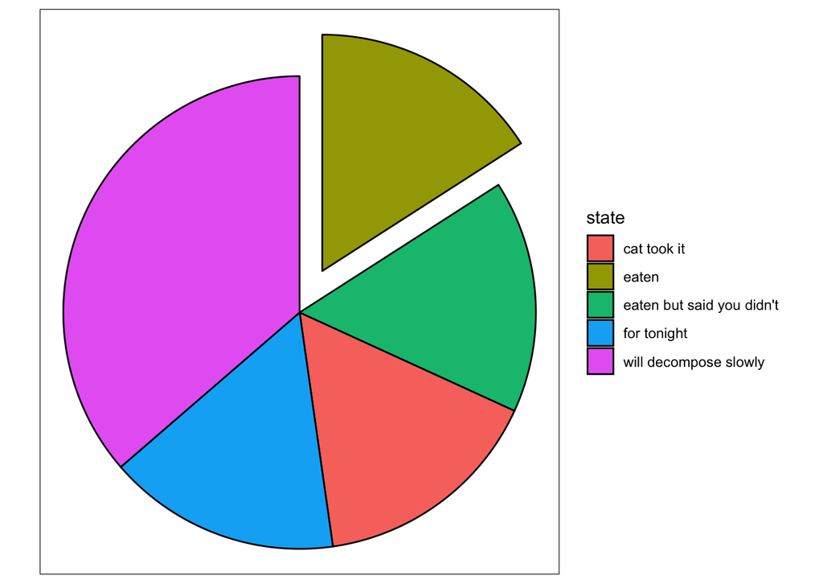

```r
# For low level control you define the start and end angles yourself
p + geom_arc_bar(aes(x0 = 0, y0 = 0, r0 = 0, r = 1, start = start, end = end,
                     fill = state, explode=focus),
                 data = pie)
```

## 2. Pie Chart 에 사용할 데이터 만들기

먼저 pie chart를 그리기 위해서는 세개의 병명에 해당하는 환자들의 명수를 구해야 합니다.

```r
data<-acs
pies="Dx"
donuts="smoking"
df=table(data[[pies]]) %>% as.data.frame
colnames(df)[1]=pies
df
```

```
               Dx Freq
1          NSTEMI  153
2           STEMI  304
3 Unstable Angina  400
```

시작각도와 끝 각도를 정해주어야 하므로 전체 인원 중 각 군에 해당하는 숫자들의 누적합계를 구하여 end로 하고 시작점을 start로 합니다. 전체 인원 수를 total에 넣은 후 start와 end를 각도로 바꾸기 위하여 2*pi로 곱하고 total로 나누어 줍니다.그리고 원호의 반지름은 r0는 0.3, r1은 1을 defalut로 하겠습니다. 시작각도 start는 0으로 합니다. 그리고 튀어나오는 파이는 explode에 저장하고 튀어나오는 거리는 explodePos에 저장합니다. 시작각도와 끝 각도의 중간 각도를 계산해 mid에 넣습니다. 파이가 튀어나올 경우 원점이 달라지므로 원점의 x,y 좌표를 계산해 x,y에 넣습니다. 이때기초적인 삼각함수가 필요합니다. 즉 튀어나오는 거리가 explodePos이고 각도가 mid이므로 x좌표는 거리*sin(각도), y좌표는 거리*cos(각도)가 됩니다. 또한 원호의 중심에 라벨을 붙이기 위해 라벨을 만듭니다. 그리고 원호의 중심좌표 labelx,labely를 구합니다. maxx는 plot의 x좌표 끝입니다.

```r
explode=1
explodePos=0.1
r0=0.3
r1=1
r2=1.2
start=0
maxx=NULL
df$end=cumsum(df$Freq)
df$start=dplyr::lag(df$end)
df$start[1]=0
total=sum(df$Freq)
df$start1=df$start*2*pi/total
df$end1=df$end*2*pi/total
df$start1=df$start1+start
df$end1=df$end1+start
df$focus=0
df$focus[explode]=explodePos
df$mid=(df$start1+df$end1)/2
df$x=ifelse(df$focus==0,0,df$focus*sin(df$mid))
df$y=ifelse(df$focus==0,0,df$focus*cos(df$mid))
df$label=df[[pies]]
df$ratio=df$Freq/sum(df$Freq)
df$label=paste0(df$label,"\n(",scales::percent(df$ratio),")")
df$labelx=(r0+r1)/2*sin(df$mid)+df$x
df$labely=(r0+r1)/2*cos(df$mid)+df$y
if(!is.factor(df[[pies]])) df[[pies]]<-factor(df[[pies]])
df
```

```
               Dx Freq end start   start1     end1 focus       mid
1          NSTEMI  153 153     0 0.000000 1.121736   0.1 0.5608678
2           STEMI  304 457   153 1.121736 3.350543   0.0 2.2361395
3 Unstable Angina  400 857   457 3.350543 6.283185   0.0 4.8168643
           x          y                    label     ratio     labelx
1 0.05319212 0.08467938          NSTEMI\n(17.9%) 0.1785298  0.3989409
2 0.00000000 0.00000000           STEMI\n(35.5%) 0.3547258  0.5113583
3 0.00000000 0.00000000 Unstable Angina\n(46.7%) 0.4667445 -0.6464558
       labely
1  0.63509538
2 -0.40126392
3  0.06778552
```

## 3. Pie Chart 그리기

ggplot의 기본 색깔은 다음과 같이 구할 수 있습니다.

```r
gg_color_hue <- function(n) {
        hues = seq(15, 375, length = n + 1)
        hcl(h = hues, l = 65, c = 100)[1:n]
}

mainCol=gg_color_hue(nrow(df))
```

가운데의 pie chart는 이 데이터로 그리면 됩니다. 나중에 파이챠트와 도넛챠트를 같이 그리려면 배경을 투명하게 만들어야 하므로 다음 함수를 사용합니다.

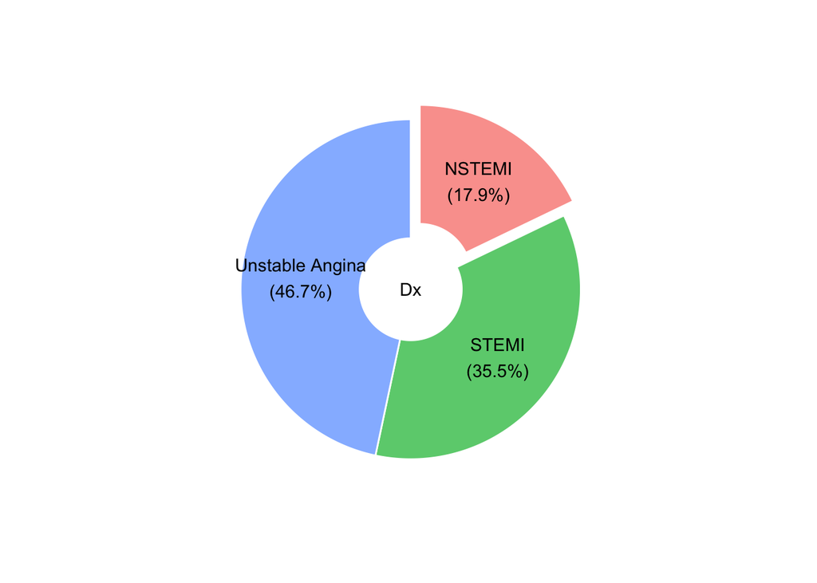

```r
transparent=function(size=0){

        temp=theme(rect= element_rect(fill = 'transparent',size=size),
                   panel.background=element_rect(fill = 'transparent'),
                   panel.border=element_rect(size=size),
                   panel.grid.major=element_blank(),
                   panel.grid.minor=element_blank())
        temp
}

 p <- ggplot() + theme_no_axes() + coord_fixed()

 if(is.null(maxx)) {
                r3=r2+0.3
        } else{
                r3=maxx
        }
 p1<-p + geom_arc_bar(aes_string(x0 = "x", y0 = "y",
                                        r0 = as.character(r0), r = as.character(r1),
                                        start="start1",end="end1",
                                        fill = pies),alpha=0.7,color="white",
                             data = df)+transparent()+
                scale_fill_manual(values=mainCol)+
                xlim(r3*c(-1,1))+ylim(r3*c(-1,1))+guides(fill=FALSE)

 p1 <-p1+geom_text(aes_string(x="labelx",y="labely",label="label"),data=df)
 p1<-p1+annotate("text",x=0,y=0,label=pies)
 p1
```

## 3. 도넛에 사용할 색깔 정하기

도넛에 사용할 색깔을 정하기 위해 다음과 같은 함수를 사용했습니다.

```r
makeSubColor=function(main,no=3){
        result=c()
        for(i in 1:length(main)){
                temp=ztable::gradientColor(main[i],n=no+2)[2:(no+1)]
                result=c(result,temp)
        }
        result
}

subColor=makeSubColor(mainCol,no=length(unique(data[[donuts]])))
subColor
```

```
[1] "#FFDED9" "#FFBCB3" "#FF9A90" "#D0EFCD" "#9FDE9C" "#69CD6C" "#DDE5FF"
[8] "#BACCFF" "#92B3FF"
```

## 4. 도넛에 사용할 데이터 만들기

도넛에 사용할 데이터를 만듭니다. 만일 도넛의 일부를 튀어나오게 만들고 싶다면 selected에 지정해줍니다(default는 NULL입니다). 파이의 경우와 마찬가지로 시작각도와 끝각도를 구합니다.

```r
selected=NULL
df3=data.frame(table(data[[donuts]],data[[pies]]),stringsAsFactors = FALSE)
colnames(df3)[1:2]=c(donuts,pies)
a=table(data[[donuts]],data[[pies]])
df3$group=rep(colSums(a),each=nrow(a))
df3$pie=rep(1:ncol(a),each=nrow(a))
total=sum(df3$Freq)

df3$ratio1=df3$Freq/total
df3$ratio=scales::percent(df3$Freq/df3$group)
df3$end=cumsum(df3$Freq)
df3$start=dplyr::lag(df3$end)
df3$start[1]=0
df3$start1=df3$start*2*pi/total
df3$end1=df3$end*2*pi/total
df3$start1=df3$start1+start
df3$end1=df3$end1+start
df3$mid=(df3$start1+df3$end1)/2
df3$focus=0

if(!is.null(selected)){
                        df3$focus[selected]=explodePos
} else if(!is.null(explode)) {
                        selected=c()
                        for(i in 1:length(explode)){
                                start=1+nrow(a)*(explode[i]-1)
                                selected=c(selected,start:(start+nrow(a)-1))
                        }
                        selected
                        df3$focus[selected]=explodePos
}
```

파이가 튀어나오는 경우 원점을 다시 계산해야 합니다. 원점의 x좌표와 y좌표를 계산합니다. 라벨을 만들고 라벨의 hjust, vjust를 구합니다.

```r
df3$x=0
df3$y=0
if(!is.null(explode)){
                        explode
                        for(i in 1:length(explode)){

                                xpos=df$focus[explode[i]]*sin(df$mid[explode[i]])
                                ypos=df$focus[explode[i]]*cos(df$mid[explode[i]])

                                df3$x[df3$pie==explode[i]]=xpos
                                df3$y[df3$pie==explode[i]]=ypos
                        }
}
df3$no=1:nrow(df3)
df3$label=df3[[donuts]]
df3$label=paste0(df3$label,"\n(",df3$ratio,")")
df3$hjust=ifelse((df3$mid %% (2*pi))>pi,1,0)
df3$vjust=ifelse(((df3$mid %% (2*pi)) <(pi/2))|(df3$mid %% (2*pi) >(pi*3/2)),0,1)
df3$no=factor(df3$no)
df3
```

```
    smoking              Dx Freq group pie     ratio1 ratio end start
1 Ex-smoker          NSTEMI   42   153   1 0.04900817 27.5%  42     0
2     Never          NSTEMI   50   153   1 0.05834306 32.7%  92    42
3    Smoker          NSTEMI   61   153   1 0.07117853 39.9% 153    92
4 Ex-smoker           STEMI   66   304   2 0.07701284 21.7% 219   153
5     Never           STEMI   97   304   2 0.11318553 31.9% 316   219
6    Smoker           STEMI  141   304   2 0.16452742 46.4% 457   316
7 Ex-smoker Unstable Angina   96   400   3 0.11201867 24.0% 553   457
8     Never Unstable Angina  185   400   3 0.21586931 46.2% 738   553
9    Smoker Unstable Angina  119   400   3 0.13885648 29.8% 857   738
     start1      end1       mid focus          x          y no
1 0.0000000 0.3079274 0.1539637   0.1 0.05319212 0.08467938  1
2 0.3079274 0.6745076 0.4912175   0.1 0.05319212 0.08467938  2
3 0.6745076 1.1217355 0.8981216   0.1 0.05319212 0.08467938  3
4 1.1217355 1.6056214 1.3636785   0.0 0.00000000 0.00000000  4
5 1.6056214 2.3167871 1.9612043   0.0 0.00000000 0.00000000  5
6 2.3167871 3.3505434 2.8336653   0.0 0.00000000 0.00000000  6
7 3.3505434 4.0543775 3.7024604   0.0 0.00000000 0.00000000  7
8 4.0543775 5.4107243 4.7325509   0.0 0.00000000 0.00000000  8
9 5.4107243 6.2831853 5.8469548   0.0 0.00000000 0.00000000  9
               label hjust vjust
1 Ex-smoker\n(27.5%)     0     0
2     Never\n(32.7%)     0     0
3    Smoker\n(39.9%)     0     0
4 Ex-smoker\n(21.7%)     0     0
5     Never\n(31.9%)     0     1
6    Smoker\n(46.4%)     0     1
7 Ex-smoker\n(24.0%)     1     1
8     Never\n(46.2%)     1     0
9    Smoker\n(29.8%)     1     0
```

라벨의 x좌표와 y좌표를 계산합니다. 또한 도넛과 라벨을 이어줄 선분의 좌표를 구합니다.

```r
explodeDonut=TRUE
df3$radius=r2
if(explodeDonut) df3$radius[df3$focus!=0]=df3$radius[df3$focus!=0]+df3$focus[df3$focus!=0]

df3$segx=df3$radius*sin(df3$mid)+df3$x
df3$segy=df3$radius*cos(df3$mid)+df3$y
df3$segxend=(df3$radius+0.05)*sin(df3$mid)+df3$x
df3$segyend=(df3$radius+0.05)*cos(df3$mid)+df3$y

df3$labelx= (df3$radius)*sin(df3$mid)+df3$x
df3$labely= (df3$radius)*cos(df3$mid)+df3$y

df3
```

```
    smoking              Dx Freq group pie     ratio1 ratio end start
1 Ex-smoker          NSTEMI   42   153   1 0.04900817 27.5%  42     0
2     Never          NSTEMI   50   153   1 0.05834306 32.7%  92    42
3    Smoker          NSTEMI   61   153   1 0.07117853 39.9% 153    92
4 Ex-smoker           STEMI   66   304   2 0.07701284 21.7% 219   153
5     Never           STEMI   97   304   2 0.11318553 31.9% 316   219
6    Smoker           STEMI  141   304   2 0.16452742 46.4% 457   316
7 Ex-smoker Unstable Angina   96   400   3 0.11201867 24.0% 553   457
8     Never Unstable Angina  185   400   3 0.21586931 46.2% 738   553
9    Smoker Unstable Angina  119   400   3 0.13885648 29.8% 857   738
     start1      end1       mid focus          x          y no
1 0.0000000 0.3079274 0.1539637   0.1 0.05319212 0.08467938  1
2 0.3079274 0.6745076 0.4912175   0.1 0.05319212 0.08467938  2
3 0.6745076 1.1217355 0.8981216   0.1 0.05319212 0.08467938  3
4 1.1217355 1.6056214 1.3636785   0.0 0.00000000 0.00000000  4
```

[output cut: 25 more lines]

## 5. 도넛 그리기

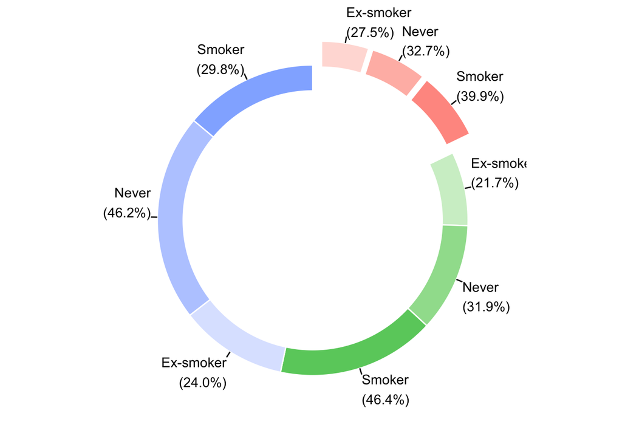

```r
p3<-p+geom_arc_bar(aes_string(x0 = "x", y0 = "y", r0 = as.character(r1),
                              r = as.character(r2), start="start1",end="end1",
                              fill="no", explode="focus"),color="white",
                   data = df3)
p3<-p3+transparent()+ scale_fill_manual(values=subColor)+
                        xlim(r3*c(-1,1))+ylim(r3*c(-1,1))+guides(fill=FALSE)



p3<-p3+ geom_segment(aes_string(x="segx",y="segy",
                                xend="segxend",yend="segyend"),data=df3)+
     geom_text(aes_string(x="segxend",y="segyend",label="label",hjust="hjust",vjust="vjust"),
              data=df3)

p3
```

## 6. 파이와 도넛 같이 그리기

두개의 같이 그리기 위해 grid 패키지의 viewport를 사용합니다.

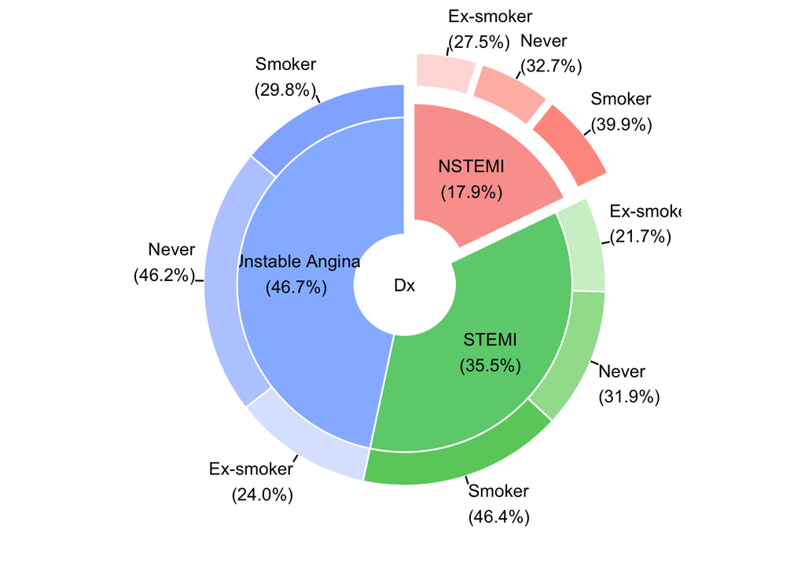

```r
require(grid)
grid::grid.newpage()
print(p1,vp=grid::viewport(height=1,width=1))
print(p3,vp=grid::viewport(height=1,width=1))
```

## 7. 기타

실제 webr 패키지에 있는 PieDonut 함수는 여러가지 옵션들을 지원하기 위해 훨씬 복잡합니다. 실제 함수의 소스를 분석하고자 하시는 분은 github 페이지를 이용하시기 바랍니다.

https://github.com/cardiomoon/webr

github페이지에서 스타를 눌러주시면 개발자들에게 큰힘이 됩니다. 긴 글 읽으시느라 수고하셨습니다.